# Introduction to Spatial Statistics

Real Data Analysis

Yang Li

2026-05-22

# Load the Packages

```r
suppressPackageStartupMessages({
  library(gstat)
  library(sp)
  library(ggplot2)
  library(dplyr)
  library(viridis)
})
```

# Introduction

We are considering the Jura soil geochemistry dataset in the `gstat` package. It includes concentrations of several heavy metals, such as cadmium, cobalt, chromium, copper, nickel, lead, and zinc.

In this analysis, we focus on **cadmium concentration** in topsoil.

The main goals are to:

- explore the spatial distribution of cadmium concentration;
- compute and model the empirical variogram;
- perform ordinary kriging;
- map the kriging prediction surface;
- map the kriging prediction variance;
- validate predictions using a separate validation dataset;
- optionally compare with universal kriging using covariates.

# Load the Data

```r
data(jura, package = "gstat")

# The jura data object loads three data frames:
# prediction.dat  = training data
# validation.dat  = validation data
# juragrid.dat    = prediction grid

head(prediction.dat)
```

```
##    Xloc  Yloc Landuse Rock    Cd     Co    Cr    Cu    Ni    Pb    Zn
## 1 2.386 3.077       3    3 1.740  9.320 38.32 25.72 21.32 77.36 92.56
## 2 2.544 1.972       2    2 1.335 10.000 40.20 24.76 29.72 77.88 73.56
## 3 2.807 3.347       2    3 1.610 10.600 47.00  8.88 21.40 30.80 64.80
## 4 4.308 1.933       3    2 2.150 11.920 43.52 22.70 29.72 56.40 90.00
## 5 4.383 1.081       3    5 1.565 16.320 38.52 34.32 26.20 66.40 88.40
## 6 3.244 4.519       3    5 1.145  3.508 40.40 31.28 22.04 72.40 75.20
```

```r
summary(prediction.dat)
```

```
##       Xloc            Yloc          Landuse           Rock
##  Min.   :0.626   Min.   :0.580   Min.   :1.000   Min.   :1.000
##  1st Qu.:2.282   1st Qu.:1.487   1st Qu.:2.000   1st Qu.:2.000
##  Median :3.043   Median :2.581   Median :3.000   Median :2.000
##  Mean   :2.980   Mean   :2.665   Mean   :2.548   Mean   :2.699
##  3rd Qu.:3.665   3rd Qu.:3.752   3rd Qu.:3.000   3rd Qu.:3.000
##  Max.   :4.920   Max.   :5.690   Max.   :4.000   Max.   :5.000
##        Cd               Co               Cr              Cu
##  Min.   :0.1350   Min.   : 1.552   Min.   : 8.72   Min.   :  3.96
##  1st Qu.:0.6375   1st Qu.: 6.520   1st Qu.:27.44   1st Qu.: 11.02
##  Median :1.0700   Median : 9.760   Median :34.84   Median : 17.60
##  Mean   :1.3091   Mean   : 9.303   Mean   :35.07   Mean   : 23.73
##  3rd Qu.:1.7150   3rd Qu.:11.980   3rd Qu.:42.22   3rd Qu.: 27.82
##  Max.   :5.1290   Max.   :17.720   Max.   :67.60   Max.   :166.40
##        Ni              Pb               Zn
##  Min.   : 4.20   Min.   : 18.96   Min.   : 25.20
##  1st Qu.:13.80   1st Qu.: 36.52   1st Qu.: 55.00
##  Median :20.56   Median : 46.40   Median : 73.56
##  Mean   :19.73   Mean   : 53.92   Mean   : 75.08
##  3rd Qu.:25.42   3rd Qu.: 60.40   3rd Qu.: 89.92
##  Max.   :53.20   Max.   :229.56   Max.   :219.32
```

The training dataset is stored in `prediction.dat`. The validation dataset is stored in `validation.dat`, and the prediction grid is stored in `juragrid.dat`.

# Response Variable: Cadmium Concentration

We use cadmium concentration, denoted by `Cd`, as the response variable.

```r
summary(prediction.dat$Cd)
```

```
##    Min. 1st Qu.  Median    Mean 3rd Qu.    Max.
##  0.1350  0.6375  1.0700  1.3091  1.7150  5.1290
```

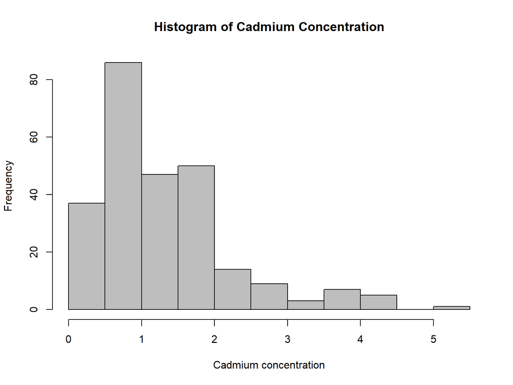

```r
hist(
  prediction.dat$Cd,
  main = "Histogram of Cadmium Concentration",
  xlab = "Cadmium concentration",
  col = "gray"
)
```

Cadmium concentration is right-skewed, so we apply a logarithmic transformation.

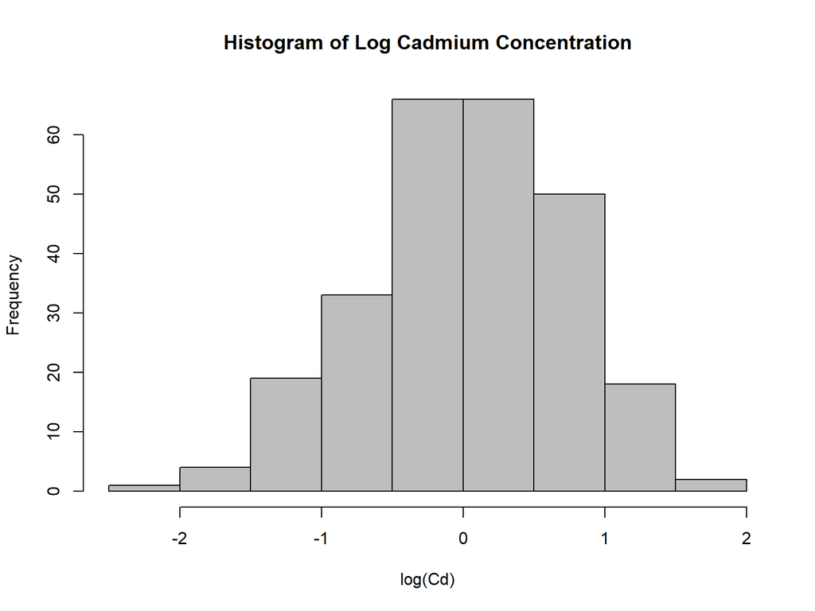

```r
prediction.dat$log_Cd <- log(prediction.dat$Cd)
validation.dat$log_Cd <- log(validation.dat$Cd)

hist(
  prediction.dat$log_Cd,
  main = "Histogram of Log Cadmium Concentration",
  xlab = "log(Cd)",
  col = "gray"
)
```

# Exploratory Spatial Plot

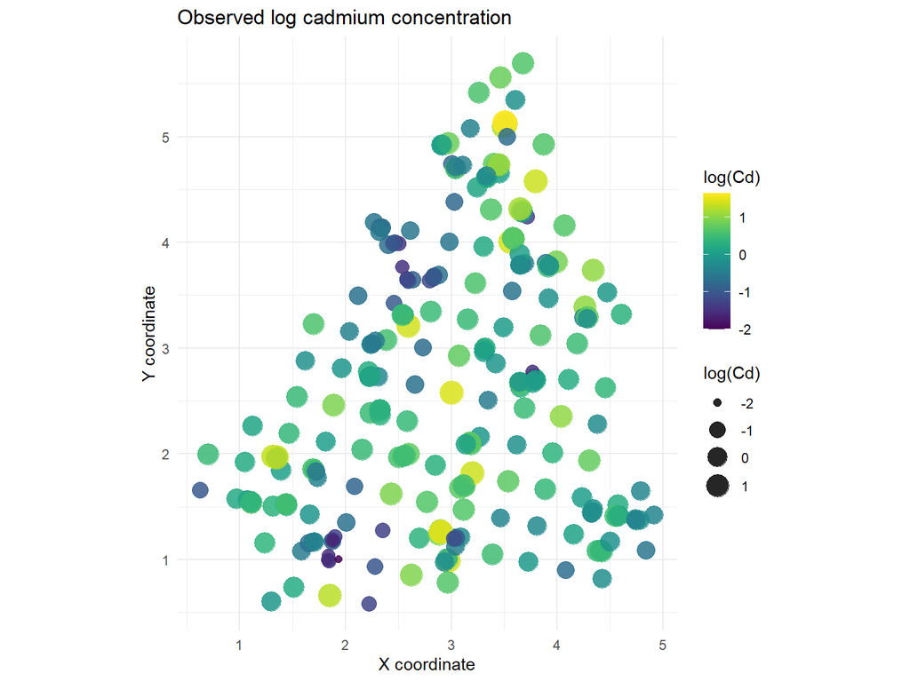

```r
ggplot(prediction.dat, aes(x = Xloc, y = Yloc, color = log_Cd, size = log_Cd)) +
  geom_point(alpha = 0.85) +
  scale_color_viridis() +
  scale_size_continuous(range = c(2, 7)) +
  coord_equal() +
  labs(
    title = "Observed log cadmium concentration",
    x = "X coordinate",
    y = "Y coordinate",
    color = "log(Cd)",
    size = "log(Cd)"
  ) +
  theme_minimal()
```

# Convert to Spatial Objects

The `gstat` package works naturally with spatial objects.

```r
train_sp <- prediction.dat
valid_sp <- validation.dat
grid_sp <- juragrid.dat

coordinates(train_sp) <- ~ Xloc + Yloc
coordinates(valid_sp) <- ~ Xloc + Yloc
coordinates(grid_sp) <- ~ Xloc + Yloc

gridded(grid_sp) <- TRUE
```

Now:

- `train_sp` contains the observed training data;
- `valid_sp` contains validation locations;
- `grid_sp` is the prediction grid.

# Empirical Semivariogram

The empirical semivariogram is defined as

$$\hat{\gamma}(h)
=
\frac{1}{2N(h)}
\sum_{(i,j)\in N(h)}
\left[
Z(s_i)-Z(s_j)
\right]^2,$$

where $N(h)$ is the set of pairs of locations separated by distance approximately $h$.

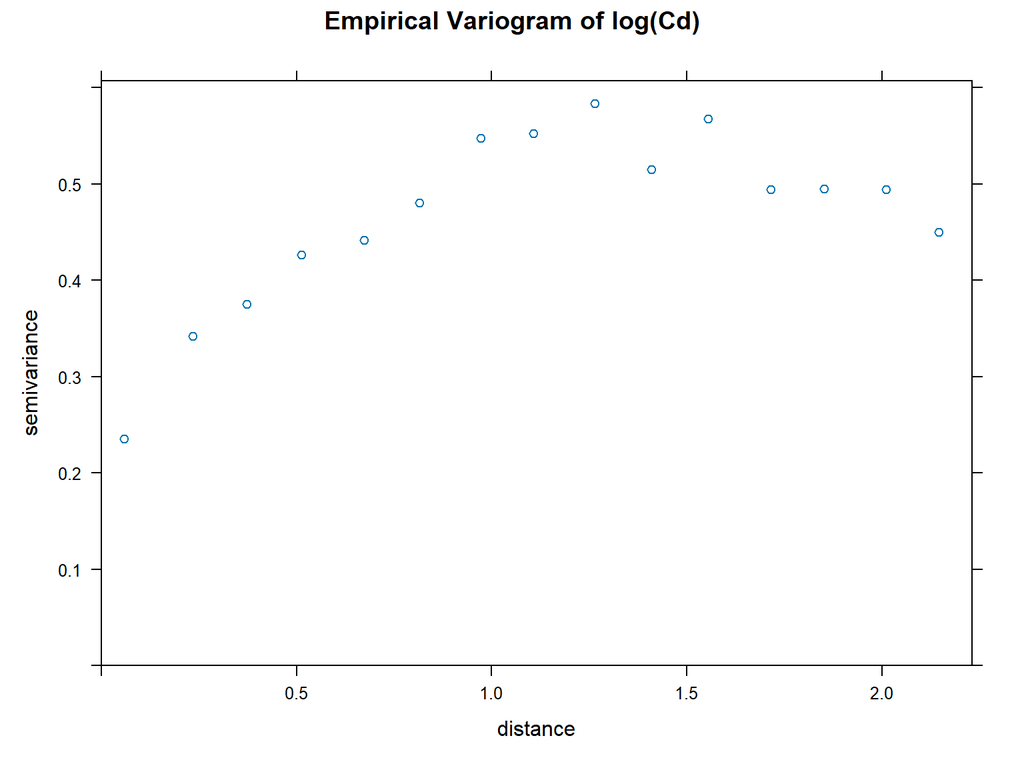

```r
emp_vario <- variogram(
  log_Cd ~ 1,
  data = train_sp
)

plot(
  emp_vario,
  main = "Empirical Variogram of log(Cd)"
)
```

The formula `log_Cd ~ 1` means that we assume an unknown but constant mean over space. This corresponds to **ordinary kriging**.

# Fit a Variogram Model

We fit an exponential variogram model.

```r
initial_model <- vgm(
  psill = 0.4,
  model = "Exp",
  range = 1.0,
  nugget = 0.05
)

fit_vario <- fit.variogram(
  emp_vario,
  model = initial_model
)

fit_vario
```

```
##   model     psill     range
## 1   Nug 0.1940533 0.0000000
## 2   Exp 0.3524335 0.4649512
```

Plot the empirical variogram together with the fitted model.

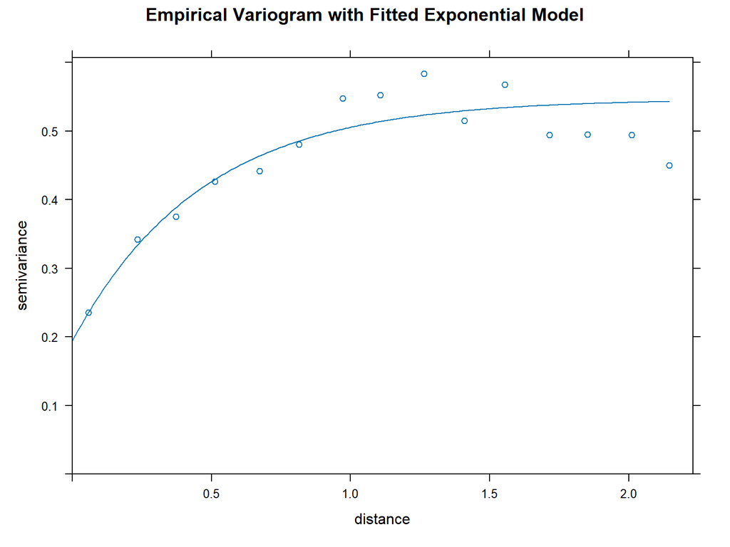

```r
plot(
  emp_vario,
  fit_vario,
  main = "Empirical Variogram with Fitted Exponential Model"
)
```

The exponential variogram model can be written as

$$\gamma(h)
=
\tau^2
+
\sigma^2
\left[
1-\exp\left(-\frac{h}{\phi}\right)
\right],$$

where:

- $\tau^2$ is the nugget effect;
- $\sigma^2$ is the partial sill;
- $\phi$ is the range parameter.

# Ordinary Kriging

Ordinary kriging predicts the value at an unsampled location $s_0$ using

$$\hat{Z}(s_0)
=
\sum_{i=1}^{n}
\lambda_i Z(s_i),$$

subject to the constraint

$$\sum_{i=1}^{n}
\lambda_i = 1.$$

The weights $\lambda_i$ are determined using the fitted variogram model.

```r
ok_result <- krige(
  formula = log_Cd ~ 1,
  locations = train_sp,
  newdata = grid_sp,
  model = fit_vario
)
```

```
## [using ordinary kriging]
```

```r
head(ok_result)
```

```
## Object of class SpatialPixelsDataFrame
## Object of class SpatialPixels
## Grid topology:
##      cellcentre.offset cellsize cells.dim
## Xloc               0.3     0.05        97
## Yloc               0.1     0.05       117
## SpatialPoints:
##   Xloc Yloc
## 1 0.30 1.70
## 2 0.35 1.70
## 3 0.35 1.75
## 4 0.40 1.70
## 5 0.40 1.75
## 6 0.40 1.80
## Coordinate Reference System (CRS) arguments: NA
##
## Data summary:
##    var1.pred          var1.var
##  Min.   :-0.2035   Min.   :0.4533
##  1st Qu.:-0.1735   1st Qu.:0.4552
##  Median :-0.1590   Median :0.4647
##  Mean   :-0.1626   Mean   :0.4662
##  3rd Qu.:-0.1430   3rd Qu.:0.4724
##  Max.   :-0.1378   Max.   :0.4878
```

The kriging output contains:

- `var1.pred`: predicted log cadmium concentration;
- `var1.var`: kriging prediction variance.

# Prepare Data for Plotting

```r
ok_df <- as.data.frame(ok_result)
train_df <- as.data.frame(train_sp)

head(ok_df)
```

```
##   Xloc Yloc  var1.pred  var1.var
## 1 0.30 1.70 -0.1414124 0.4878021
## 2 0.35 1.70 -0.1703794 0.4720402
## 3 0.35 1.75 -0.1477074 0.4725185
## 4 0.40 1.70 -0.2034950 0.4532569
## 5 0.40 1.75 -0.1745753 0.4545364
## 6 0.40 1.80 -0.1378288 0.4572714
```

# Kriging Prediction Surface

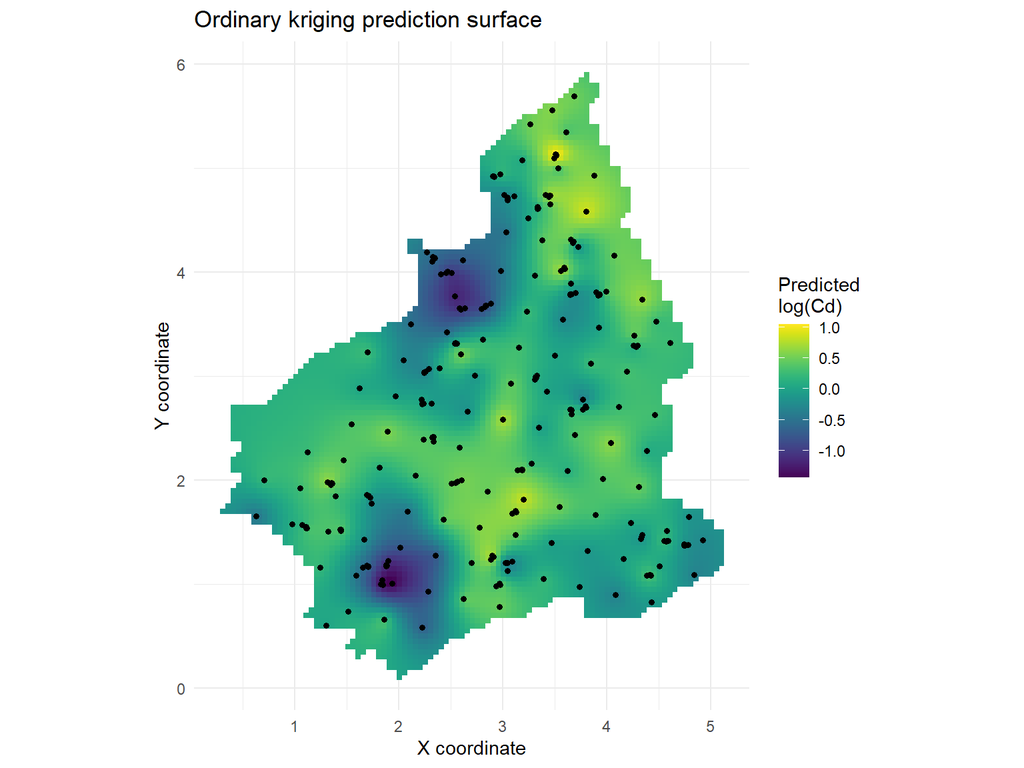

```r
ggplot() +
  geom_raster(
    data = ok_df,
    aes(x = Xloc, y = Yloc, fill = var1.pred)
  ) +
  geom_point(
    data = train_df,
    aes(x = Xloc, y = Yloc),
    color = "black",
    size = 1.2
  ) +
  scale_fill_viridis(name = "Predicted\nlog(Cd)") +
  coord_equal() +
  labs(
    title = "Ordinary kriging prediction surface",
    x = "X coordinate",
    y = "Y coordinate"
  ) +
  theme_minimal()
```

This map shows the predicted spatial surface of log cadmium concentration.

# Overlay Observed Values

In this plot, the background shows the kriging prediction surface, while the observed points are represented using both size and color.

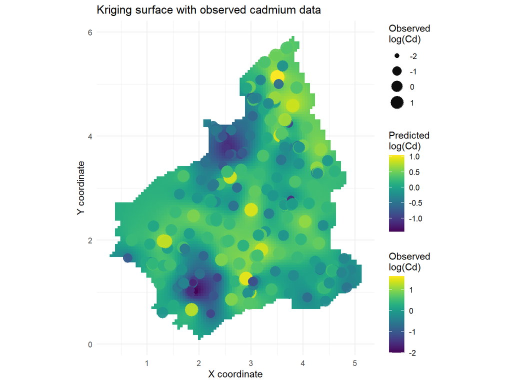

```r
ggplot() +
  geom_raster(
    data = ok_df,
    aes(x = Xloc, y = Yloc, fill = var1.pred)
  ) +
  geom_point(
    data = train_df,
    aes(x = Xloc, y = Yloc, size = log_Cd, color = log_Cd),
    alpha = 0.95
  ) +
  scale_fill_viridis(name = "Predicted\nlog(Cd)") +
  scale_color_viridis(name = "Observed\nlog(Cd)") +
  scale_size_continuous(range = c(2, 7), name = "Observed\nlog(Cd)") +
  coord_equal() +
  labs(
    title = "Kriging surface with observed cadmium data",
    x = "X coordinate",
    y = "Y coordinate"
  ) +
  theme_minimal()
```

This plot helps compare the observed cadmium values with the predicted spatial surface.

# Kriging Prediction Variance

The kriging prediction variance measures the uncertainty of the prediction at each location.

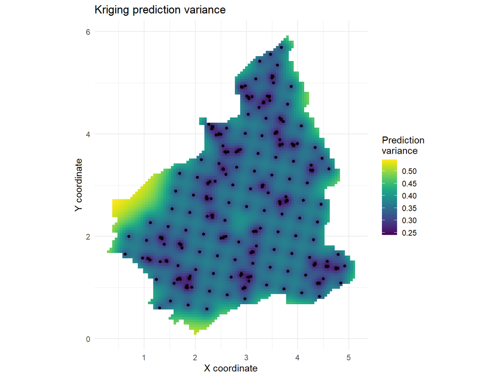

```r
ggplot() +
  geom_raster(
    data = ok_df,
    aes(x = Xloc, y = Yloc, fill = var1.var)
  ) +
  geom_point(
    data = train_df,
    aes(x = Xloc, y = Yloc),
    color = "black",
    size = 1.2
  ) +
  scale_fill_viridis(name = "Prediction\nvariance") +
  coord_equal() +
  labs(
    title = "Kriging prediction variance",
    x = "X coordinate",
    y = "Y coordinate"
  ) +
  theme_minimal()
```

The prediction variance is usually smaller near observed sampling locations and larger in areas farther from observations.

# Back-Transform Predictions

Because the model was fitted on the log scale, the predictions are also on the log scale.

A simple back-transformation is

$$\widehat{\text{Cd}}(s_0)
=
\exp
\left[
\widehat{\log(\text{Cd})}(s_0)
\right].$$

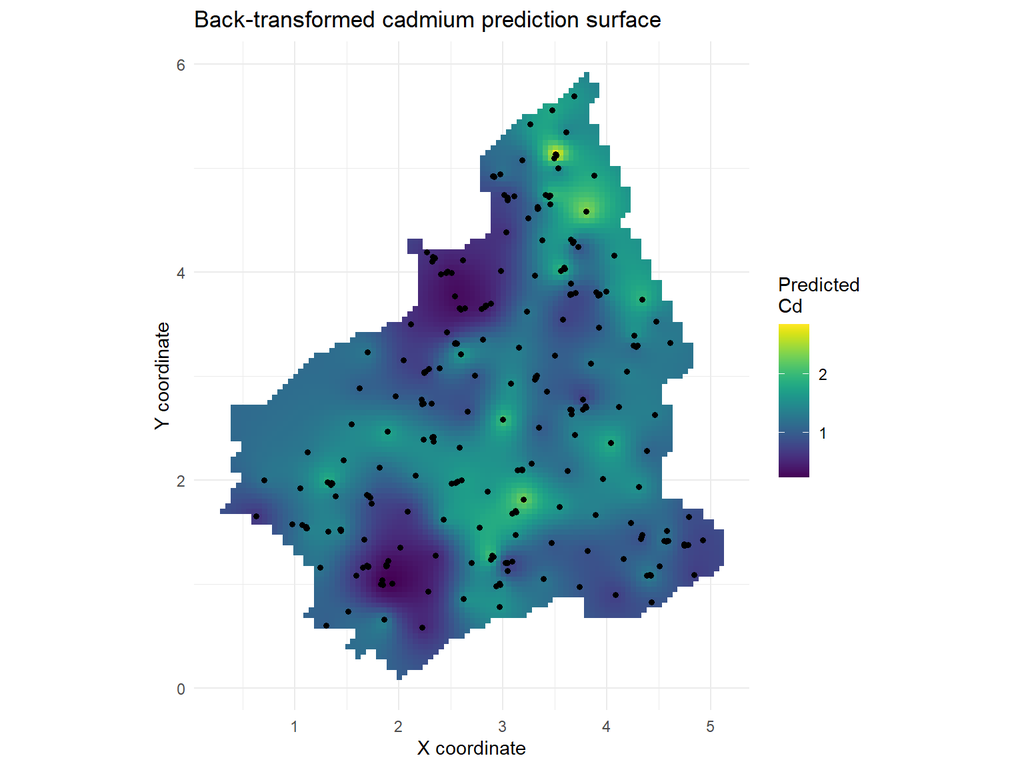

```r
ok_df$Cd_pred <- exp(ok_df$var1.pred)

ggplot() +
  geom_raster(
    data = ok_df,
    aes(x = Xloc, y = Yloc, fill = Cd_pred)
  ) +
  geom_point(
    data = train_df,
    aes(x = Xloc, y = Yloc),
    color = "black",
    size = 1.2
  ) +
  scale_fill_viridis(name = "Predicted\nCd") +
  coord_equal() +
  labs(
    title = "Back-transformed cadmium prediction surface",
    x = "X coordinate",
    y = "Y coordinate"
  ) +
  theme_minimal()
```

This simple transformation gives predictions on the original cadmium scale.

A technical note: the simple exponential back-transformation gives a median-type prediction on the original scale. A bias-corrected back-transformation may be used if the mean on the original scale is required.

# Validation Using the Validation Dataset

The Jura dataset includes a separate validation dataset. We use it to evaluate prediction performance.

```r
valid_pred <- krige(
  formula = log_Cd ~ 1,
  locations = train_sp,
  newdata = valid_sp,
  model = fit_vario
)
```

```
## [using ordinary kriging]
```

```r
valid_pred_df <- as.data.frame(valid_pred)
valid_df <- as.data.frame(valid_sp)

validation_results <- data.frame(
  observed = valid_df$log_Cd,
  predicted = valid_pred_df$var1.pred
)

validation_results$error <- validation_results$observed -
  validation_results$predicted

head(validation_results)
```

```
##     observed  predicted      error
## 1  0.4510756 -0.7022277  1.1533034
## 2  0.7153978  0.5520649  0.1633329
## 3  0.1848184  0.6160654 -0.4312470
## 4 -0.7133499  0.2636889 -0.9770388
## 5 -0.3681693  0.1839418 -0.5521112
## 6  0.5596158  0.1226219  0.4369939
```

Compute validation summaries.

```r
mean_error <- mean(validation_results$error)
rmse <- sqrt(mean(validation_results$error^2))
mae <- mean(abs(validation_results$error))

data.frame(
  Mean_Error = mean_error,
  RMSE = rmse,
  MAE = mae
)
```

```
##    Mean_Error      RMSE       MAE
## 1 -0.05216502 0.5651087 0.4500128
```

A good prediction model should have mean error close to zero and relatively small RMSE and MAE.

# Observed Versus Predicted Validation Plot

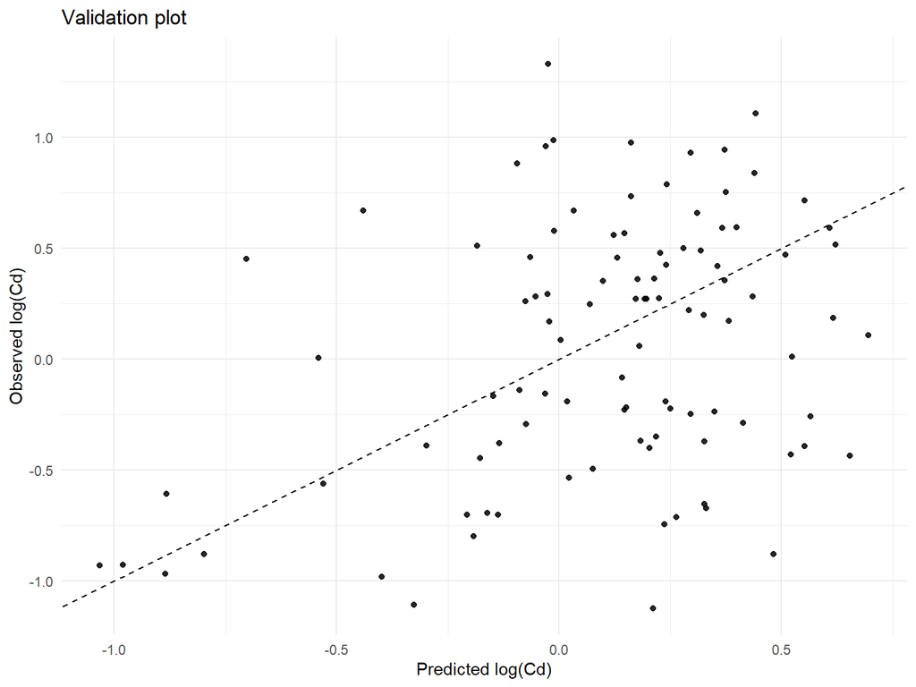

```r
ggplot(validation_results, aes(x = predicted, y = observed)) +
  geom_point(alpha = 0.85) +
  geom_abline(
    intercept = 0,
    slope = 1,
    linetype = "dashed"
  ) +
  labs(
    title = "Validation plot",
    x = "Predicted log(Cd)",
    y = "Observed log(Cd)"
  ) +
  theme_minimal()
```

Points close to the dashed line indicate better prediction performance.

# Universal Kriging with Covariates

The Jura dataset includes covariates such as land use and rock type. These can be used in universal kriging.

Universal kriging allows the mean structure to depend on covariates:

$$Z(s)
=
\beta_0
+
\beta_1 X_1(s)
+
\beta_2 X_2(s)
+
\varepsilon(s).$$

Here, we include `Landuse` and `Rock` as covariates.

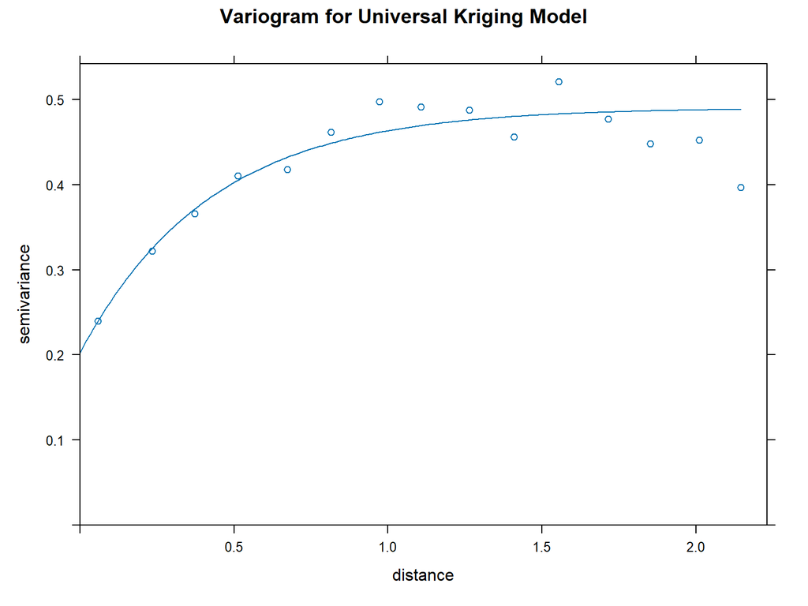

```r
emp_vario_uk <- variogram(
  log_Cd ~ Landuse + Rock,
  data = train_sp
)

initial_model_uk <- vgm(
  psill = 0.3,
  model = "Exp",
  range = 1.0,
  nugget = 0.05
)

fit_vario_uk <- fit.variogram(
  emp_vario_uk,
  model = initial_model_uk
)

plot(
  emp_vario_uk,
  fit_vario_uk,
  main = "Variogram for Universal Kriging Model"
)
```

Perform universal kriging.

```r
uk_result <- krige(
  formula = log_Cd ~ Landuse + Rock,
  locations = train_sp,
  newdata = grid_sp,
  model = fit_vario_uk
)
```

```
## [using universal kriging]
```

```r
uk_df <- as.data.frame(uk_result)
```

Plot the universal kriging prediction surface.

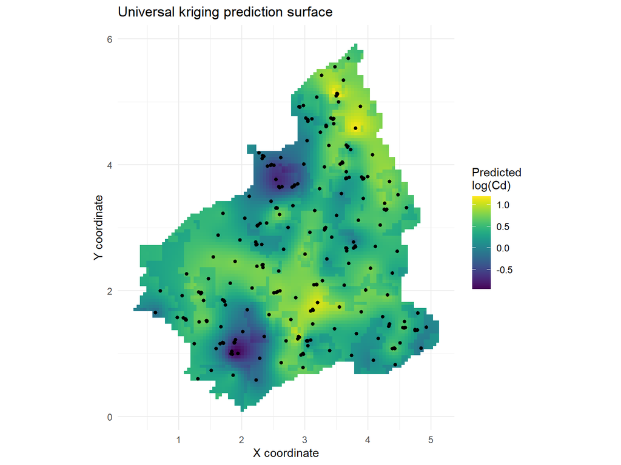

```r
ggplot() +
  geom_raster(
    data = uk_df,
    aes(x = Xloc, y = Yloc, fill = var1.pred)
  ) +
  geom_point(
    data = train_df,
    aes(x = Xloc, y = Yloc),
    color = "black",
    size = 1.2
  ) +
  scale_fill_viridis(name = "Predicted\nlog(Cd)") +
  coord_equal() +
  labs(
    title = "Universal kriging prediction surface",
    x = "X coordinate",
    y = "Y coordinate"
  ) +
  theme_minimal()
```

# Compare Ordinary and Universal Kriging

We can compare the two models using the validation dataset.

```r
uk_valid_pred <- krige(
  formula = log_Cd ~ Landuse + Rock,
  locations = train_sp,
  newdata = valid_sp,
  model = fit_vario_uk
)
```

```
## [using universal kriging]
```

```r
uk_valid_pred_df <- as.data.frame(uk_valid_pred)

uk_validation_results <- data.frame(
  observed = valid_df$log_Cd,
  predicted = uk_valid_pred_df$var1.pred
)

uk_validation_results$error <- uk_validation_results$observed -
  uk_validation_results$predicted

comparison <- data.frame(
  Model = c("Ordinary kriging", "Universal kriging"),
  Mean_Error = c(
    mean(validation_results$error),
    mean(uk_validation_results$error)
  ),
  RMSE = c(
    sqrt(mean(validation_results$error^2)),
    sqrt(mean(uk_validation_results$error^2))
  ),
  MAE = c(
    mean(abs(validation_results$error)),
    mean(abs(uk_validation_results$error))
  )
)

comparison
```

```
##               Model  Mean_Error      RMSE       MAE
## 1  Ordinary kriging -0.05216502 0.5651087 0.4500128
## 2 Universal kriging -0.05583267 0.5736756 0.4550778
```

The model with smaller RMSE and MAE has better predictive performance on the validation dataset. The two kriging methods have similar performance.